# Connectsionist Bench

Cho dữ liệu **sonar.all-data.txt**  
Yêu cầu: Đọc dữ liệu, chuẩn hóa dữ liệu (nếu cần) và chọn một **thuật toán thích hợp** để thực hiện việc xác định một mẫu là **mine (M)** hay **rock (R)** dựa trên các thông tin được cung cấp.

1. Tạo X_train, X_test, y_train, y_test từ dữ liệu đọc và được chuẩn hóa, với tỷ lệ dữ liệu test là 0.3
2. Áp dụng thuật toán thích hợp để xây dựng model. Dựa trên cơ sở nào để cho rằng thuật toán này thích hợp?
3. Đánh giá model dựa trên train/test.
4. Trực quan hóa kết quả (nếu có). Đưa ra một số nhận xét dựa trên kết quả.
5. Hãy cho biết với X_new (từng giá trị ứng với từng cột trong dataset) như sau thì mẫu nào là mine (M), mẫu nào là rock (R) ?  
   X_new = [[0.0123,0.0309,0.0169,0.0313,0.0358,0.0102,0.0182,0.0579,0.1122,0.0835,0.05 48,0.0847,0.2026,0.2557,0.1870,0.2032,0.1463,0.2849,0.5824,0.7728,0.7852,0.8 515,0.5312,0.3653,0.5973,0.8275,1.0000,0.8673,0.6301,0.4591,0.3940,0.2576,0. 2817,0.2641,0.2757,0.2698,0.3994,0.4576,0.3940,0.2522,0.1782,0.1354,0.0516, 0.0337,0.0894,0.0861,0.0872,0.0445,0.0134,0.0217,0.0188,0.0133,0.0265,0.022 4,0.0074,0.0118,0.0026,0.0092,0.0009,0.0044], [0.0203,0.0121,0.0380,0.0128,0.0537,0.0874,0.1021,0.0852,0.1136,0.1747,0.219 8,0.2721,0.2105,0.1727,0.2040,0.1786,0.1318,0.2260,0.2358,0.3107,0.3906,0.36 31,0.4809,0.6531,0.7812,0.8395,0.9180,0.9769,0.8937,0.7022,0.6500,0.5069,0.3 903,0.3009,0.1565,0.0985,0.2200,0.2243,0.2736,0.2152,0.2438,0.3154,0.2112,0. 0991,0.0594,0.1940,0.1937,0.1082,0.0336,0.0177,0.0209,0.0134,0.0094,0.0047, 0.0045,0.0042,0.0028,0.0036,0.0013,0.0016]]

**---------------------------------------------------- DATA OVERVIEW ----------------------------------------------------------**

```python
import pandas as pd
data = pd.read_csv('du lieu cung cap/sonar.all-data.txt', header=None)
```

```python
data.info()
```

```
<class 'pandas.core.frame.DataFrame'>
RangeIndex: 208 entries, 0 to 207
Data columns (total 61 columns):
0     208 non-null float64
1     208 non-null float64
2     208 non-null float64
3     208 non-null float64
4     208 non-null float64
5     208 non-null float64
6     208 non-null float64
7     208 non-null float64
8     208 non-null float64
9     208 non-null float64
10    208 non-null float64
11    208 non-null float64
```

[output cut: 51 more lines]

```python
print('Number of rows:',data.shape[0])
print('Number of columns:',data.shape[1])
```

```
Number of rows: 208
Number of columns: 61
```

```python
data.head()
```

|  | 0 | 1 | 2 | 3 | 4 | 5 | 6 | 7 | 8 | 9 | ... | 51 | 52 | 53 | 54 | 55 | 56 | 57 | 58 | 59 | 60 |
| --- | --- | --- | --- | --- | --- | --- | --- | --- | --- | --- | --- | --- | --- | --- | --- | --- | --- | --- | --- | --- | --- |
| 0 | 0.0200 | 0.0371 | 0.0428 | 0.0207 | 0.0954 | 0.0986 | 0.1539 | 0.1601 | 0.3109 | 0.2111 | ... | 0.0027 | 0.0065 | 0.0159 | 0.0072 | 0.0167 | 0.0180 | 0.0084 | 0.0090 | 0.0032 | R |
| 1 | 0.0453 | 0.0523 | 0.0843 | 0.0689 | 0.1183 | 0.2583 | 0.2156 | 0.3481 | 0.3337 | 0.2872 | ... | 0.0084 | 0.0089 | 0.0048 | 0.0094 | 0.0191 | 0.0140 | 0.0049 | 0.0052 | 0.0044 | R |
| 2 | 0.0262 | 0.0582 | 0.1099 | 0.1083 | 0.0974 | 0.2280 | 0.2431 | 0.3771 | 0.5598 | 0.6194 | ... | 0.0232 | 0.0166 | 0.0095 | 0.0180 | 0.0244 | 0.0316 | 0.0164 | 0.0095 | 0.0078 | R |
| 3 | 0.0100 | 0.0171 | 0.0623 | 0.0205 | 0.0205 | 0.0368 | 0.1098 | 0.1276 | 0.0598 | 0.1264 | ... | 0.0121 | 0.0036 | 0.0150 | 0.0085 | 0.0073 | 0.0050 | 0.0044 | 0.0040 | 0.0117 | R |
| 4 | 0.0762 | 0.0666 | 0.0481 | 0.0394 | 0.0590 | 0.0649 | 0.1209 | 0.2467 | 0.3564 | 0.4459 | ... | 0.0031 | 0.0054 | 0.0105 | 0.0110 | 0.0015 | 0.0072 | 0.0048 | 0.0107 | 0.0094 | R |

5 rows × 61 columns

```python
descrip = data.describe(include='all').transpose()
pd.options.display.max_rows = 1000
display(descrip)
pd.options.display.max_rows = 15
```

|  | count | unique | top | freq | mean | std | min | 25% | 50% | 75% | max |
| --- | --- | --- | --- | --- | --- | --- | --- | --- | --- | --- | --- |
| 0 | 208 | NaN | NaN | NaN | 0.0291639 | 0.0229909 | 0.0015 | 0.01335 | 0.0228 | 0.03555 | 0.1371 |
| 1 | 208 | NaN | NaN | NaN | 0.0384365 | 0.0329599 | 0.0006 | 0.01645 | 0.0308 | 0.04795 | 0.2339 |
| 2 | 208 | NaN | NaN | NaN | 0.0438322 | 0.0384281 | 0.0015 | 0.01895 | 0.0343 | 0.05795 | 0.3059 |
| 3 | 208 | NaN | NaN | NaN | 0.0538923 | 0.046528 | 0.0058 | 0.024375 | 0.04405 | 0.0645 | 0.4264 |
| 4 | 208 | NaN | NaN | NaN | 0.0752024 | 0.0555522 | 0.0067 | 0.03805 | 0.0625 | 0.100275 | 0.401 |
| 5 | 208 | NaN | NaN | NaN | 0.10457 | 0.0591054 | 0.0102 | 0.067025 | 0.09215 | 0.134125 | 0.3823 |
| 6 | 208 | NaN | NaN | NaN | 0.121747 | 0.0617879 | 0.0033 | 0.0809 | 0.10695 | 0.154 | 0.3729 |
| 7 | 208 | NaN | NaN | NaN | 0.134799 | 0.0851522 | 0.0055 | 0.080425 | 0.1121 | 0.1696 | 0.459 |
| 8 | 208 | NaN | NaN | NaN | 0.178003 | 0.118387 | 0.0075 | 0.097025 | 0.15225 | 0.233425 | 0.6828 |
| 9 | 208 | NaN | NaN | NaN | 0.208259 | 0.134416 | 0.0113 | 0.111275 | 0.1824 | 0.2687 | 0.7106 |
| 10 | 208 | NaN | NaN | NaN | 0.236013 | 0.132705 | 0.0289 | 0.12925 | 0.2248 | 0.30165 | 0.7342 |
| 11 | 208 | NaN | NaN | NaN | 0.250221 | 0.140072 | 0.0236 | 0.133475 | 0.24905 | 0.33125 | 0.706 |
| 12 | 208 | NaN | NaN | NaN | 0.273305 | 0.140962 | 0.0184 | 0.166125 | 0.26395 | 0.35125 | 0.7131 |
| 13 | 208 | NaN | NaN | NaN | 0.296568 | 0.164474 | 0.0273 | 0.175175 | 0.2811 | 0.386175 | 0.997 |
| 14 | 208 | NaN | NaN | NaN | 0.320201 | 0.205427 | 0.0031 | 0.164625 | 0.2817 | 0.452925 | 1 |
| 15 | 208 | NaN | NaN | NaN | 0.378487 | 0.23265 | 0.0162 | 0.1963 | 0.3047 | 0.535725 | 0.9988 |
| 16 | 208 | NaN | NaN | NaN | 0.415983 | 0.263677 | 0.0349 | 0.20585 | 0.3084 | 0.659425 | 1 |
| 17 | 208 | NaN | NaN | NaN | 0.452318 | 0.261529 | 0.0375 | 0.242075 | 0.3683 | 0.67905 | 1 |
| 18 | 208 | NaN | NaN | NaN | 0.504812 | 0.257988 | 0.0494 | 0.299075 | 0.43495 | 0.7314 | 1 |
| 19 | 208 | NaN | NaN | NaN | 0.563047 | 0.262653 | 0.0656 | 0.350625 | 0.5425 | 0.809325 | 1 |
| 20 | 208 | NaN | NaN | NaN | 0.60906 | 0.257818 | 0.0512 | 0.399725 | 0.6177 | 0.816975 | 1 |
| 21 | 208 | NaN | NaN | NaN | 0.624275 | 0.255883 | 0.0219 | 0.406925 | 0.6649 | 0.831975 | 1 |
| 22 | 208 | NaN | NaN | NaN | 0.646975 | 0.250175 | 0.0563 | 0.450225 | 0.6997 | 0.848575 | 1 |
| 23 | 208 | NaN | NaN | NaN | 0.672654 | 0.239116 | 0.0239 | 0.540725 | 0.6985 | 0.872175 | 1 |
| 24 | 208 | NaN | NaN | NaN | 0.675424 | 0.244926 | 0.024 | 0.5258 | 0.7211 | 0.873725 | 1 |
| 25 | 208 | NaN | NaN | NaN | 0.699866 | 0.237228 | 0.0921 | 0.544175 | 0.7545 | 0.8938 | 1 |
| 26 | 208 | NaN | NaN | NaN | 0.702155 | 0.245657 | 0.0481 | 0.5319 | 0.7456 | 0.9171 | 1 |
| 27 | 208 | NaN | NaN | NaN | 0.694024 | 0.237189 | 0.0284 | 0.534775 | 0.7319 | 0.900275 | 1 |
| 28 | 208 | NaN | NaN | NaN | 0.642074 | 0.24025 | 0.0144 | 0.4637 | 0.6808 | 0.852125 | 1 |
| 29 | 208 | NaN | NaN | NaN | 0.580928 | 0.220749 | 0.0613 | 0.4114 | 0.60715 | 0.735175 | 1 |
| 30 | 208 | NaN | NaN | NaN | 0.504475 | 0.213992 | 0.0482 | 0.34555 | 0.49035 | 0.64195 | 0.9657 |
| 31 | 208 | NaN | NaN | NaN | 0.43904 | 0.213237 | 0.0404 | 0.2814 | 0.4296 | 0.5803 | 0.9306 |
| 32 | 208 | NaN | NaN | NaN | 0.41722 | 0.206513 | 0.0477 | 0.257875 | 0.3912 | 0.556125 | 1 |
| 33 | 208 | NaN | NaN | NaN | 0.403233 | 0.231242 | 0.0212 | 0.217575 | 0.35105 | 0.596125 | 0.9647 |
| 34 | 208 | NaN | NaN | NaN | 0.392571 | 0.259132 | 0.0223 | 0.179375 | 0.31275 | 0.59335 | 1 |
| 35 | 208 | NaN | NaN | NaN | 0.384848 | 0.264121 | 0.008 | 0.15435 | 0.32115 | 0.556525 | 1 |
| 36 | 208 | NaN | NaN | NaN | 0.363807 | 0.239912 | 0.0351 | 0.1601 | 0.3063 | 0.5189 | 0.9497 |
| 37 | 208 | NaN | NaN | NaN | 0.339657 | 0.212973 | 0.0383 | 0.174275 | 0.3127 | 0.44055 | 1 |
| 38 | 208 | NaN | NaN | NaN | 0.3258 | 0.199075 | 0.0371 | 0.173975 | 0.2835 | 0.4349 | 0.9857 |
| 39 | 208 | NaN | NaN | NaN | 0.311207 | 0.178662 | 0.0117 | 0.18645 | 0.27805 | 0.42435 | 0.9297 |
| 40 | 208 | NaN | NaN | NaN | 0.289252 | 0.171111 | 0.036 | 0.1631 | 0.2595 | 0.387525 | 0.8995 |
| 41 | 208 | NaN | NaN | NaN | 0.278293 | 0.168728 | 0.0056 | 0.1589 | 0.2451 | 0.38425 | 0.8246 |
| 42 | 208 | NaN | NaN | NaN | 0.246542 | 0.138993 | 0 | 0.1552 | 0.22255 | 0.324525 | 0.7733 |
| 43 | 208 | NaN | NaN | NaN | 0.214075 | 0.133291 | 0 | 0.126875 | 0.1777 | 0.27175 | 0.7762 |
| 44 | 208 | NaN | NaN | NaN | 0.197232 | 0.151628 | 0 | 0.094475 | 0.148 | 0.23155 | 0.7034 |
| 45 | 208 | NaN | NaN | NaN | 0.160631 | 0.133938 | 0 | 0.06855 | 0.12135 | 0.200375 | 0.7292 |
| 46 | 208 | NaN | NaN | NaN | 0.122453 | 0.0869527 | 0 | 0.06425 | 0.10165 | 0.154425 | 0.5522 |
| 47 | 208 | NaN | NaN | NaN | 0.091424 | 0.0624167 | 0 | 0.045125 | 0.0781 | 0.1201 | 0.3339 |
| 48 | 208 | NaN | NaN | NaN | 0.0519288 | 0.035954 | 0 | 0.02635 | 0.0447 | 0.068525 | 0.1981 |
| 49 | 208 | NaN | NaN | NaN | 0.020424 | 0.013665 | 0 | 0.01155 | 0.0179 | 0.025275 | 0.0825 |
| 50 | 208 | NaN | NaN | NaN | 0.0160688 | 0.0120085 | 0 | 0.008425 | 0.0139 | 0.020825 | 0.1004 |
| 51 | 208 | NaN | NaN | NaN | 0.0134202 | 0.00963399 | 0.0008 | 0.007275 | 0.0114 | 0.016725 | 0.0709 |
| 52 | 208 | NaN | NaN | NaN | 0.0107091 | 0.00706034 | 0.0005 | 0.005075 | 0.00955 | 0.0149 | 0.039 |
| 53 | 208 | NaN | NaN | NaN | 0.0109409 | 0.0073008 | 0.001 | 0.005375 | 0.0093 | 0.0145 | 0.0352 |
| 54 | 208 | NaN | NaN | NaN | 0.00929038 | 0.00708763 | 0.0006 | 0.00415 | 0.0075 | 0.0121 | 0.0447 |
| 55 | 208 | NaN | NaN | NaN | 0.00822163 | 0.00573611 | 0.0004 | 0.0044 | 0.00685 | 0.010575 | 0.0394 |
| 56 | 208 | NaN | NaN | NaN | 0.00782019 | 0.0057855 | 0.0003 | 0.0037 | 0.00595 | 0.010425 | 0.0355 |
| 57 | 208 | NaN | NaN | NaN | 0.00794904 | 0.00646984 | 0.0003 | 0.0036 | 0.0058 | 0.01035 | 0.044 |
| 58 | 208 | NaN | NaN | NaN | 0.00794135 | 0.00618138 | 0.0001 | 0.003675 | 0.0064 | 0.010325 | 0.0364 |
| 59 | 208 | NaN | NaN | NaN | 0.00650721 | 0.00503104 | 0.0006 | 0.0031 | 0.0053 | 0.008525 | 0.0439 |
| 60 | 208 | 2 | M | 111 | NaN | NaN | NaN | NaN | NaN | NaN | NaN |

**1. Tạo X_train, X_test, y_train, y_test từ dữ liệu đã đọc và chuẩn hóa, với tỷ lệ dữ liệu test là 0.3**

```python
inputs = data.iloc[:,0:-1]
inputs.shape
```

```
(208, 60)
```

```python
inputs.head()
```

|  | 0 | 1 | 2 | 3 | 4 | 5 | 6 | 7 | 8 | 9 | ... | 50 | 51 | 52 | 53 | 54 | 55 | 56 | 57 | 58 | 59 |
| --- | --- | --- | --- | --- | --- | --- | --- | --- | --- | --- | --- | --- | --- | --- | --- | --- | --- | --- | --- | --- | --- |
| 0 | 0.0200 | 0.0371 | 0.0428 | 0.0207 | 0.0954 | 0.0986 | 0.1539 | 0.1601 | 0.3109 | 0.2111 | ... | 0.0232 | 0.0027 | 0.0065 | 0.0159 | 0.0072 | 0.0167 | 0.0180 | 0.0084 | 0.0090 | 0.0032 |
| 1 | 0.0453 | 0.0523 | 0.0843 | 0.0689 | 0.1183 | 0.2583 | 0.2156 | 0.3481 | 0.3337 | 0.2872 | ... | 0.0125 | 0.0084 | 0.0089 | 0.0048 | 0.0094 | 0.0191 | 0.0140 | 0.0049 | 0.0052 | 0.0044 |
| 2 | 0.0262 | 0.0582 | 0.1099 | 0.1083 | 0.0974 | 0.2280 | 0.2431 | 0.3771 | 0.5598 | 0.6194 | ... | 0.0033 | 0.0232 | 0.0166 | 0.0095 | 0.0180 | 0.0244 | 0.0316 | 0.0164 | 0.0095 | 0.0078 |
| 3 | 0.0100 | 0.0171 | 0.0623 | 0.0205 | 0.0205 | 0.0368 | 0.1098 | 0.1276 | 0.0598 | 0.1264 | ... | 0.0241 | 0.0121 | 0.0036 | 0.0150 | 0.0085 | 0.0073 | 0.0050 | 0.0044 | 0.0040 | 0.0117 |
| 4 | 0.0762 | 0.0666 | 0.0481 | 0.0394 | 0.0590 | 0.0649 | 0.1209 | 0.2467 | 0.3564 | 0.4459 | ... | 0.0156 | 0.0031 | 0.0054 | 0.0105 | 0.0110 | 0.0015 | 0.0072 | 0.0048 | 0.0107 | 0.0094 |

5 rows × 60 columns

```python
import numpy as np
outputs = data[60]
outputs = np.array(outputs)
outputs.shape
```

```
(208,)
```

```python
outputs
```

```
array(['R', 'R', 'R', 'R', 'R', 'R', 'R', 'R', 'R', 'R', 'R', 'R', 'R',
       'R', 'R', 'R', 'R', 'R', 'R', 'R', 'R', 'R', 'R', 'R', 'R', 'R',
       'R', 'R', 'R', 'R', 'R', 'R', 'R', 'R', 'R', 'R', 'R', 'R', 'R',
       'R', 'R', 'R', 'R', 'R', 'R', 'R', 'R', 'R', 'R', 'R', 'R', 'R',
       'R', 'R', 'R', 'R', 'R', 'R', 'R', 'R', 'R', 'R', 'R', 'R', 'R',
       'R', 'R', 'R', 'R', 'R', 'R', 'R', 'R', 'R', 'R', 'R', 'R', 'R',
       'R', 'R', 'R', 'R', 'R', 'R', 'R', 'R', 'R', 'R', 'R', 'R', 'R',
       'R', 'R', 'R', 'R', 'R', 'R', 'M', 'M', 'M', 'M', 'M', 'M', 'M',
       'M', 'M', 'M', 'M', 'M', 'M', 'M', 'M', 'M', 'M', 'M', 'M', 'M',
       'M', 'M', 'M', 'M', 'M', 'M', 'M', 'M', 'M', 'M', 'M', 'M', 'M',
       'M', 'M', 'M', 'M', 'M', 'M', 'M', 'M', 'M', 'M', 'M', 'M', 'M',
       'M', 'M', 'M', 'M', 'M', 'M', 'M', 'M', 'M', 'M', 'M', 'M', 'M',
       'M', 'M', 'M', 'M', 'M', 'M', 'M', 'M', 'M', 'M', 'M', 'M', 'M',
       'M', 'M', 'M', 'M', 'M', 'M', 'M', 'M', 'M', 'M', 'M', 'M', 'M',
       'M', 'M', 'M', 'M', 'M', 'M', 'M', 'M', 'M', 'M', 'M', 'M', 'M',
       'M', 'M', 'M', 'M', 'M', 'M', 'M', 'M', 'M', 'M', 'M', 'M', 'M'],
      dtype=object)
```

```python
from sklearn.model_selection import train_test_split
X_train, X_test, y_train, y_test = train_test_split(inputs, outputs,
                                                    test_size=0.30,
                                                    random_state=42)
```

**2. Áp dụng thuật toán thích hợp để xây dựng model. Dựa trên cơ sở nào để cho rằng thuật toán này thích hợp?**

**3. Đánh giá model dựa trên train/test**

**4. Trực quan hóa kết quả (nếu có). Đưa ra một số nhận xét dựa trên kết quả**

Đây là bài toán Classification thuộc nhóm Supervised Learning. Output là binary class và dữ liệu input nhiều chiều.  
Một số model có thể dùng cho dạng bài toán này:

```
1. Logistic Regression
2. Navie Bayer - GaussianNB
3. KNN - Classification
4. Decision Tree
5. Random Forest
```

**---------------------------------------------------- 1. LOGISTIC REGRESSION ----------------------------------------------------------**

```python
from sklearn.linear_model import LogisticRegression
clf = LogisticRegression(solver='liblinear')
```

```python
LG = clf.fit(X_train,y_train)
```

```python
print('Training data/ Score: ', clf.score(X_train,y_train))
print('Testing data/ Score learn: ', clf.score(X_test,y_test))
```

```
Training data/ Score:  0.7862068965517242
Testing data/ Score learn:  0.8253968253968254
```

**Nhận xét:** Score tương đối cao, khá phù hợp

**------------------------------------------------------ End - Logistic Regression -------------------------------------------------------**

**---------------------------------------------------- 2. NAVIE BAYER ----------------------------------------------------------**

```python
from sklearn.naive_bayes import GaussianNB
import numpy as np
from sklearn.utils.validation import column_or_1d

#Create a Gaussian Classifier
model = GaussianNB()
# Train the model using the training sets
model.fit(X_train, column_or_1d(y_train))
```

```
GaussianNB(priors=None, var_smoothing=1e-09)
```

```python
print('Training data/ Score: ', model.score(X_train,y_train))
print('Testing data/ Score learn: ', model.score(X_test,y_test))
```

```
Training data/ Score:  0.7586206896551724
Testing data/ Score learn:  0.7777777777777778
```

**Nhận xét:** Score tương đối, không tốt hơn Logistic Regression

**------------------------------------------------------ End - NAVIE NAYER -------------------------------------------------------**

**---------------------------------------------------- 3. KNN CLASSISFICATION ----------------------------------------------------------**

**Tìm best K**

```python
from sklearn.metrics import accuracy_score
from sklearn.neighbors import KNeighborsClassifier
list_k = []
list_acc = []
for K_value in range(1,int(y_train.shape[0]**0.5)):
    list_k.append(K_value)
    neigh = KNeighborsClassifier(n_neighbors = K_value)
    neigh.fit(X_train, y_train)
    y_pred = neigh.predict(X_test)
    acc = accuracy_score(y_test,y_pred)*100
    list_acc.append(acc)
    print("Accuracy is ", accuracy_score(y_test,y_pred)*100,"% for K-Value:",K_value)
```

```
Accuracy is  90.47619047619048 % for K-Value: 1
Accuracy is  84.12698412698413 % for K-Value: 2
Accuracy is  88.88888888888889 % for K-Value: 3
Accuracy is  85.71428571428571 % for K-Value: 4
Accuracy is  84.12698412698413 % for K-Value: 5
Accuracy is  73.01587301587301 % for K-Value: 6
Accuracy is  74.60317460317461 % for K-Value: 7
Accuracy is  73.01587301587301 % for K-Value: 8
Accuracy is  73.01587301587301 % for K-Value: 9
Accuracy is  74.60317460317461 % for K-Value: 10
Accuracy is  69.84126984126983 % for K-Value: 11
```

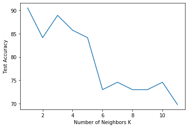

```python
import matplotlib.pyplot as plt
plt.plot(list_k, list_acc)
plt.xlabel('Number of Neighbors K')
plt.ylabel('Test Accuracy')
plt.show()
```

```python
vi_tri = list_acc.index(max(list_acc))
k = list_k[vi_tri]
print("The optimal number of neighbors is", k,"with", list_acc[vi_tri])
```

```
The optimal number of neighbors is 1 with 90.47619047619048
```

**Nhận xét:** k = 1 với score cao cho thấy tập dữ liệu khá gần nhau.

```python
# select k => ap dung model
knn = KNeighborsClassifier(n_neighbors=1)
knn.fit(X_train, y_train)
```

```
KNeighborsClassifier(algorithm='auto', leaf_size=30, metric='minkowski',
           metric_params=None, n_jobs=None, n_neighbors=1, p=2,
           weights='uniform')
```

```python
y_pred = knn.predict(X_test)
```

```python
# Kiểm tra độ chính xác
print("The Train prediction accuracy is: ",
      knn.score(X_train,y_train)*100,"%")
print("The Test prediction accuracy is: ",
      knn.score(X_test,y_test)*100,"%")
```

```
The Train prediction accuracy is:  100.0 %
The Test prediction accuracy is:  90.47619047619048 %
```

**Nhận xét:** Score khá cao dù k = 1

**------------------------------------------------------ End - KNN -------------------------------------------------------**

**---------------------------------------------------- 4. DECISIONTREE CLASSIFIER ----------------------------------------------------------**

```python
from sklearn.tree import DecisionTreeClassifier
```

```python
clf = DecisionTreeClassifier(criterion='entropy') # nen dung Gini vi day la thuoc tinh lien tuc
tree_model = clf.fit(X_train, y_train)
```

```python
# Kiểm tra độ chính xác
print("The Train prediction accuracy is: ", tree_model.score(X_train, y_train)*100,"%")
print("The Test prediction accuracy is: ", tree_model.score(X_test, y_test)*100,"%")
```

```
The Train prediction accuracy is:  100.0 %
The Test prediction accuracy is:  73.01587301587301 %
```

**Nhận xét:** Overfitting

**------------------------------------------------------ End - Decision Tree -------------------------------------------------------**

**---------------------------------------------------- 5. RANDOM FOREST ----------------------------------------------------------**

**Chọn số lượng cây n_estimators phù hợp**

```python
from sklearn.ensemble import RandomForestClassifier
list_n = []
list_acc = []
for n_estimators in [10, 30, 50, 70, 100, 120, 150, 170, 200, 250, 300]:
    list_n.append(n_estimators)
    clf = RandomForestClassifier(n_estimators = n_estimators)
    forest_model = clf.fit(X_train, y_train)
    y_pred = forest_model.predict(X_test)
    acc = accuracy_score(y_test,y_pred)*100
    list_acc.append(acc)
    print("Accuracy is ", accuracy_score(y_test,y_pred)*100,"% for n_estimators:",n_estimators)
```

```
Accuracy is  77.77777777777779 % for n_estimators: 10
Accuracy is  88.88888888888889 % for n_estimators: 30
Accuracy is  84.12698412698413 % for n_estimators: 50
Accuracy is  84.12698412698413 % for n_estimators: 70
Accuracy is  88.88888888888889 % for n_estimators: 100
Accuracy is  80.95238095238095 % for n_estimators: 120
Accuracy is  80.95238095238095 % for n_estimators: 150
Accuracy is  82.53968253968253 % for n_estimators: 170
Accuracy is  85.71428571428571 % for n_estimators: 200
Accuracy is  87.3015873015873 % for n_estimators: 250
Accuracy is  80.95238095238095 % for n_estimators: 300
```

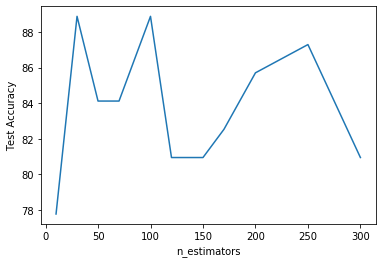

```python
import matplotlib.pyplot as plt
plt.plot(list_n, list_acc)
plt.xlabel('n_estimators')
plt.ylabel('Test Accuracy')
plt.show()
```

```python
vi_tri = list_acc.index(max(list_acc))
n = list_n[vi_tri]
print("The optimal n_estimators is", n,"with", list_acc[vi_tri])
```

```
The optimal n_estimators is 30 with 88.88888888888889
```

```python
clf = RandomForestClassifier(n_estimators = n)
forest_model = clf.fit(X_train, y_train)
```

```python
y_pred = forest_model.predict(X_test)
```

```python
# Kiểm tra độ chính xác
print("The Training prediction accuracy is: ",
      forest_model.score(X_train,y_train)*100,"%")
print("The Testing prediction accuracy is: ",
      forest_model.score(X_test,y_test)*100,"%")
```

```
The Training prediction accuracy is:  100.0 %
The Testing prediction accuracy is:  79.36507936507937 %
```

**Nhận xét:** Overfitting

**------------------------------------------------------ End - Random Forest -------------------------------------------------------**

**KẾT LUẬN: CÓ THỂ DÙNG LOGISTIC REGRESSION OR KNN CHO BÀI TOÁN NÀY**

**Try Feature Selection:** Thử chọn lọc fearture để xem có thể giảm độ nhiễu, tăng score cho Model được hay không?

```python
#get correlations of each features in dataset
data_sub = inputs
corrmat = data_sub.corr()
top_corr_features = corrmat.index
```

```python
data_sub.corr()
```

|  | 0 | 1 | 2 | 3 | 4 | 5 | 6 | 7 | 8 | 9 | ... | 50 | 51 | 52 | 53 | 54 | 55 | 56 | 57 | 58 | 59 |
| --- | --- | --- | --- | --- | --- | --- | --- | --- | --- | --- | --- | --- | --- | --- | --- | --- | --- | --- | --- | --- | --- |
| 0 | 1.000000 | 0.735896 | 0.571537 | 0.491438 | 0.344797 | 0.238921 | 0.260815 | 0.355523 | 0.353420 | 0.318276 | ... | 0.254450 | 0.355299 | 0.311729 | 0.322299 | 0.312067 | 0.220642 | 0.313725 | 0.368132 | 0.357116 | 0.347078 |
| 1 | 0.735896 | 1.000000 | 0.779916 | 0.606684 | 0.419669 | 0.332329 | 0.279040 | 0.334615 | 0.316733 | 0.270782 | ... | 0.320538 | 0.434548 | 0.346076 | 0.383960 | 0.380165 | 0.262263 | 0.280341 | 0.353042 | 0.352200 | 0.358761 |
| 2 | 0.571537 | 0.779916 | 1.000000 | 0.781786 | 0.546141 | 0.346275 | 0.190434 | 0.237884 | 0.252691 | 0.219637 | ... | 0.238110 | 0.394076 | 0.332914 | 0.367186 | 0.289731 | 0.287661 | 0.380819 | 0.334108 | 0.425047 | 0.373948 |
| 3 | 0.491438 | 0.606684 | 0.781786 | 1.000000 | 0.726943 | 0.352805 | 0.246440 | 0.246742 | 0.247078 | 0.237769 | ... | 0.174676 | 0.374651 | 0.364772 | 0.334211 | 0.284955 | 0.280938 | 0.340254 | 0.344865 | 0.420266 | 0.400626 |
| 4 | 0.344797 | 0.419669 | 0.546141 | 0.726943 | 1.000000 | 0.597053 | 0.335422 | 0.204006 | 0.177906 | 0.183219 | ... | 0.115936 | 0.266617 | 0.314985 | 0.205306 | 0.196472 | 0.199323 | 0.219395 | 0.238793 | 0.290982 | 0.253710 |
| 5 | 0.238921 | 0.332329 | 0.346275 | 0.352805 | 0.597053 | 1.000000 | 0.702889 | 0.471683 | 0.327578 | 0.288621 | ... | 0.171767 | 0.252288 | 0.162404 | 0.164073 | 0.133464 | 0.166758 | 0.161333 | 0.203986 | 0.220573 | 0.178158 |
| 6 | 0.260815 | 0.279040 | 0.190434 | 0.246440 | 0.335422 | 0.702889 | 1.000000 | 0.675774 | 0.470580 | 0.425448 | ... | 0.184152 | 0.144051 | 0.046403 | 0.163074 | 0.195541 | 0.174143 | 0.186324 | 0.242646 | 0.183578 | 0.222493 |
| ... | ... | ... | ... | ... | ... | ... | ... | ... | ... | ... | ... | ... | ... | ... | ... | ... | ... | ... | ... | ... | ... |
| 53 | 0.322299 | 0.383960 | 0.367186 | 0.334211 | 0.205306 | 0.164073 | 0.163074 | 0.234008 | 0.202615 | 0.146725 | ... | 0.384052 | 0.343190 | 0.412337 | 1.000000 | 0.455059 | 0.397378 | 0.361443 | 0.404117 | 0.447118 | 0.283471 |
| 54 | 0.312067 | 0.380165 | 0.289731 | 0.284955 | 0.196472 | 0.133464 | 0.195541 | 0.239551 | 0.179342 | 0.175254 | ... | 0.278935 | 0.337581 | 0.315656 | 0.455059 | 1.000000 | 0.429948 | 0.387204 | 0.503465 | 0.453658 | 0.264399 |
| 55 | 0.220642 | 0.262263 | 0.287661 | 0.280938 | 0.199323 | 0.166758 | 0.174143 | 0.276819 | 0.232764 | 0.151889 | ... | 0.209752 | 0.203121 | 0.421588 | 0.397378 | 0.429948 | 1.000000 | 0.515154 | 0.463659 | 0.430804 | 0.349449 |
| 56 | 0.313725 | 0.280341 | 0.380819 | 0.340254 | 0.219395 | 0.161333 | 0.186324 | 0.267212 | 0.193963 | 0.140327 | ... | 0.191407 | 0.191264 | 0.308197 | 0.361443 | 0.387204 | 0.515154 | 1.000000 | 0.509805 | 0.431295 | 0.287219 |
| 57 | 0.368132 | 0.353042 | 0.334108 | 0.344865 | 0.238793 | 0.203986 | 0.242646 | 0.287603 | 0.231745 | 0.212277 | ... | 0.325665 | 0.309673 | 0.370764 | 0.404117 | 0.503465 | 0.463659 | 0.509805 | 1.000000 | 0.550235 | 0.329827 |
| 58 | 0.357116 | 0.352200 | 0.425047 | 0.420266 | 0.290982 | 0.220573 | 0.183578 | 0.194400 | 0.097293 | 0.058273 | ... | 0.317942 | 0.298711 | 0.346095 | 0.447118 | 0.453658 | 0.430804 | 0.431295 | 0.550235 | 1.000000 | 0.642872 |
| 59 | 0.347078 | 0.358761 | 0.373948 | 0.400626 | 0.253710 | 0.178158 | 0.222493 | 0.146216 | 0.095243 | 0.097358 | ... | 0.246764 | 0.195379 | 0.280780 | 0.283471 | 0.264399 | 0.349449 | 0.287219 | 0.329827 | 0.642872 | 1.000000 |

60 rows × 60 columns

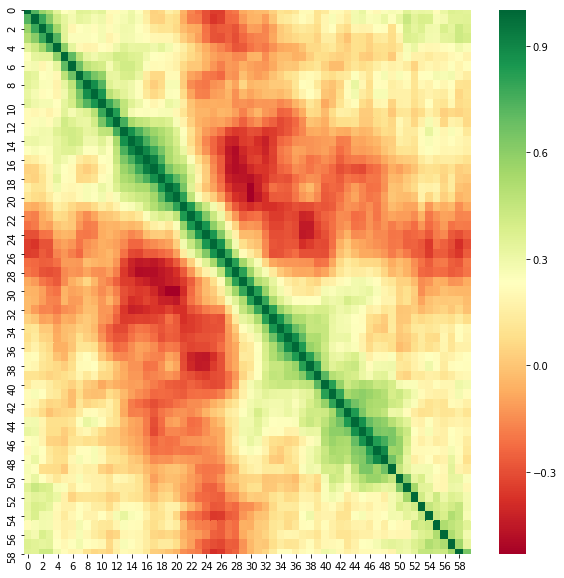

```python
import seaborn as sns
plt.figure(figsize=(10,10))
#plot heat map
g=sns.heatmap(data[top_corr_features].corr(),cmap="RdYlGn") # annot=True: nếu muốn in cả giá trị
```

=> Quá nhiều inputs, không nhìn được sự tương quan giữa các biến

```python
from sklearn.feature_selection import SelectKBest
from sklearn.feature_selection import chi2
```

```python
#apply SelectKBest class to extract all best features
bestfeatures = SelectKBest(score_func=chi2, k='all')
fit = bestfeatures.fit(inputs,outputs)
dfscores = pd.DataFrame(fit.scores_)
dfcolumns = pd.DataFrame(inputs.columns)
```

```python
#concat two dataframes for better visualization
featureScores = pd.concat([dfcolumns,dfscores],axis=1)
featureScores.columns = ['Specs','Score']  #naming the dataframe columns
pd.options.display.max_rows = 1000
display(featureScores.sort_values(by='Score',ascending=False))
pd.options.display.max_rows = 15
```

|  | Specs | Score |
| --- | --- | --- |
| 10 | 10 | 2.893951e+00 |
| 44 | 44 | 2.779667e+00 |
| 35 | 35 | 2.718192e+00 |
| 11 | 11 | 2.497266e+00 |
| 45 | 45 | 2.159148e+00 |
| 9 | 9 | 2.089953e+00 |
| 34 | 34 | 1.835295e+00 |
| 8 | 8 | 1.684129e+00 |
| 12 | 12 | 1.472619e+00 |
| 36 | 36 | 1.431281e+00 |
| 20 | 20 | 1.331296e+00 |
| 43 | 43 | 1.287674e+00 |
| 19 | 19 | 1.273892e+00 |
| 46 | 46 | 1.163346e+00 |
| 47 | 47 | 9.567154e-01 |
| 42 | 42 | 8.887617e-01 |
| 21 | 21 | 8.802975e-01 |
| 33 | 33 | 8.121846e-01 |
| 48 | 48 | 6.359780e-01 |
| 3 | 3 | 5.223566e-01 |
| 18 | 18 | 5.212966e-01 |
| 13 | 13 | 4.670624e-01 |
| 41 | 41 | 4.400030e-01 |
| 4 | 4 | 4.195205e-01 |
| 7 | 7 | 3.990634e-01 |
| 22 | 22 | 3.250852e-01 |
| 1 | 1 | 3.128362e-01 |
| 0 | 0 | 2.769472e-01 |
| 2 | 2 | 2.576072e-01 |
| 32 | 32 | 2.430878e-01 |
| 30 | 30 | 2.303802e-01 |
| 50 | 50 | 1.597008e-01 |
| 5 | 5 | 1.210908e-01 |
| 51 | 51 | 1.192802e-01 |
| 27 | 27 | 1.141678e-01 |
| 23 | 23 | 9.645952e-02 |
| 14 | 14 | 8.962696e-02 |
| 6 | 6 | 8.546992e-02 |
| 38 | 38 | 8.155143e-02 |
| 31 | 31 | 6.550021e-02 |
| 49 | 49 | 6.147164e-02 |
| 26 | 26 | 5.381097e-02 |
| 37 | 37 | 4.540135e-02 |
| 57 | 57 | 3.698109e-02 |
| 53 | 53 | 3.365716e-02 |
| 39 | 39 | 2.740567e-02 |
| 28 | 28 | 2.498006e-02 |
| 52 | 52 | 1.939345e-02 |
| 58 | 58 | 1.704650e-02 |
| 55 | 55 | 1.385851e-02 |
| 25 | 25 | 1.310880e-02 |
| 24 | 24 | 1.177337e-02 |
| 54 | 54 | 1.023775e-02 |
| 40 | 40 | 9.189494e-03 |
| 17 | 17 | 6.683067e-03 |
| 59 | 59 | 6.529959e-03 |
| 15 | 15 | 3.970062e-03 |
| 16 | 16 | 5.450145e-04 |
| 29 | 29 | 3.090607e-04 |
| 56 | 56 | 7.709688e-07 |

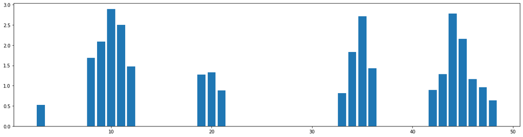

```python
#visualization feature selection
nlargest = 20 # xem thử 100 biến có score lớn nhất

plt.figure(figsize = (20,5))
plt.bar(featureScores.nlargest(nlargest,'Score').Specs.values
        , featureScores.nlargest(nlargest,'Score').Score.values)
plt.show()
```

**5. Hãy cho biết với X_new (từng giá trị ứng với từng cột trong dataset) như sau thì mẫu nào là mine (M), mẫu nào là rock (R) ?**  
X_new = [[0.0123,0.0309,0.0169,0.0313,0.0358,0.0102,0.0182,0.0579,0.1122,0.0835,0.05 48,0.0847,0.2026,0.2557,0.1870,0.2032,0.1463,0.2849,0.5824,0.7728,0.7852,0.8 515,0.5312,0.3653,0.5973,0.8275,1.0000,0.8673,0.6301,0.4591,0.3940,0.2576,0. 2817,0.2641,0.2757,0.2698,0.3994,0.4576,0.3940,0.2522,0.1782,0.1354,0.0516, 0.0337,0.0894,0.0861,0.0872,0.0445,0.0134,0.0217,0.0188,0.0133,0.0265,0.022 4,0.0074,0.0118,0.0026,0.0092,0.0009,0.0044], [0.0203,0.0121,0.0380,0.0128,0.0537,0.0874,0.1021,0.0852,0.1136,0.1747,0.219 8,0.2721,0.2105,0.1727,0.2040,0.1786,0.1318,0.2260,0.2358,0.3107,0.3906,0.36 31,0.4809,0.6531,0.7812,0.8395,0.9180,0.9769,0.8937,0.7022,0.6500,0.5069,0.3 903,0.3009,0.1565,0.0985,0.2200,0.2243,0.2736,0.2152,0.2438,0.3154,0.2112,0. 0991,0.0594,0.1940,0.1937,0.1082,0.0336,0.0177,0.0209,0.0134,0.0094,0.0047, 0.0045,0.0042,0.0028,0.0036,0.0013,0.0016]]

```python
X_new = [[0.0123,0.0309,0.0169,0.0313,0.0358,0.0102,0.0182,0.0579,0.1122,0.0835,0.0548,0.0847,0.2026,0.2557,0.1870,0.2032
          ,0.1463,0.2849,0.5824,0.7728,0.7852,0.8515,0.5312,0.3653,0.5973,0.8275,1.0000,0.8673,0.6301,0.4591,0.3940,0.2576
          ,0.2817,0.2641,0.2757,0.2698,0.3994,0.4576,0.3940,0.2522,0.1782,0.1354,0.0516, 0.0337,0.0894,0.0861,0.0872,0.0445
          ,0.0134,0.0217,0.0188,0.0133,0.0265,0.0224,0.0074,0.0118,0.0026,0.0092,0.0009,0.0044],
         [0.0203,0.0121,0.0380,0.0128,0.0537,0.0874,0.1021,0.0852,0.1136,0.1747,0.2198,0.2721,0.2105,0.1727,0.2040,0.1786
          ,0.1318,0.2260,0.2358,0.3107,0.3906,0.3631,0.4809,0.6531,0.7812,0.8395,0.9180,0.9769,0.8937,0.7022,0.6500,0.5069
          ,0.3903,0.3009,0.1565,0.0985,0.2200,0.2243,0.2736,0.2152,0.2438,0.3154,0.2112,0.0991,0.0594,0.1940,0.1937,0.1082
          ,0.0336,0.0177,0.0209,0.0134,0.0094,0.0047, 0.0045,0.0042,0.0028,0.0036,0.0013,0.0016]]
```

```python
y_new = LG.predict(X_new)
y_new
```

```
array(['R', 'M'], dtype=object)
```

```python
y_new = knn.predict(X_new)
y_new
```

```
array(['R', 'M'], dtype=object)
```